# 20_fef_dist_ellipse

## 20_fef_dist_ellipse

#### Question

1. An [ellipse](https://en.wikipedia.org/wiki/Ellipse) is a set of points such that the total distance from (1) one focus to (2) the edge to (3) the other focus is constant for any point on the edge. The two foci ($F_1$ and $F_2$) are a distance $2c$ apart, and the total distance from $F_1$ to the edge to $F_2$ is a distance $2a$.

   Let’s consider the example below with foci at $(-6,0)$ and $(6,0)$ and a covertex at $(0, 2.5)$:

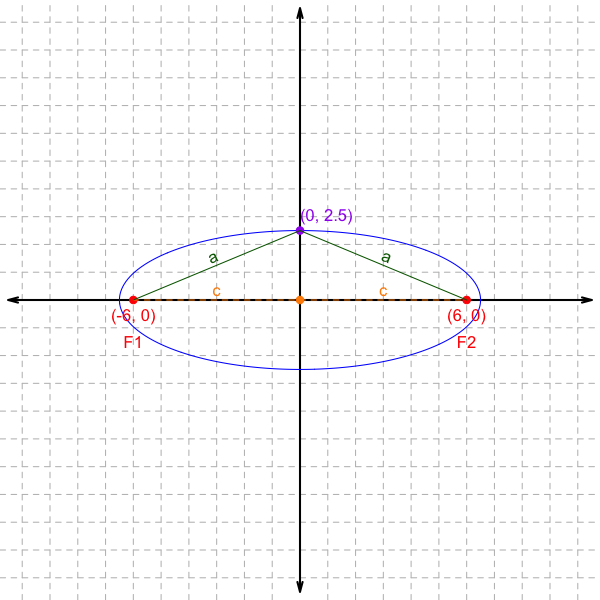

   Evaluate $2a$ and $2c$.
   - $a=$
   - $2a=$
   - $c=$
   - $2c=$

   Now, let’s pick another point on the ellipse, with (approximate) coordinates (5.2, 1.5):

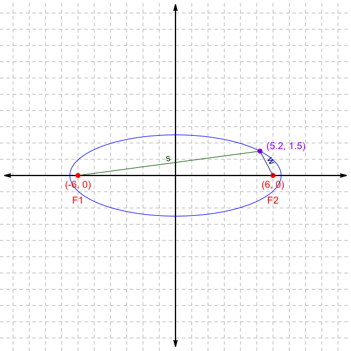

   The distance $s$ is from $F_1$ to the point on the edge. The distance $w$ is from $F_2$ to the point on the edge. Evaluate $s$, $w$, and the total distance ($s+w$).
   - $s=$
   - $w=$
   - $s+w=$

   Remember, the total distance when connecting
   1. The first focus $F_1$
   2. Any point on the edge
   3. The second focus $F_2$

   equals $2a$. Based on this information, find the location of the right vertex at ($x$, 0) in the diagram below.

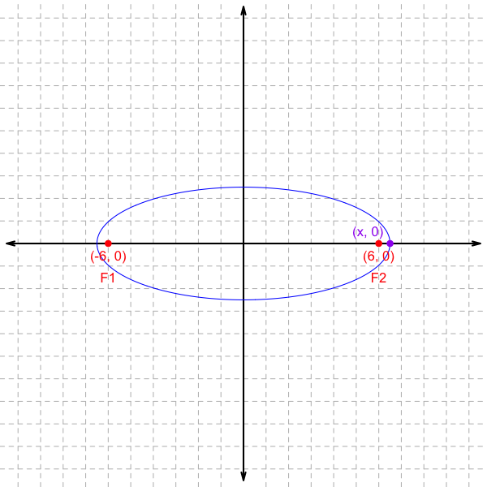

   - $x=$

#### Solution

#### Question

2. An [ellipse](https://en.wikipedia.org/wiki/Ellipse) is a set of points such that the total distance from (1) one focus to (2) the edge to (3) the other focus is constant for any point on the edge. The two foci ($F_1$ and $F_2$) are a distance $2c$ apart, and the total distance from $F_1$ to the edge to $F_2$ is a distance $2a$.

   Let’s consider the example below with foci at $(-1.6,0)$ and $(1.6,0)$ and a covertex at $(0, 6.3)$:

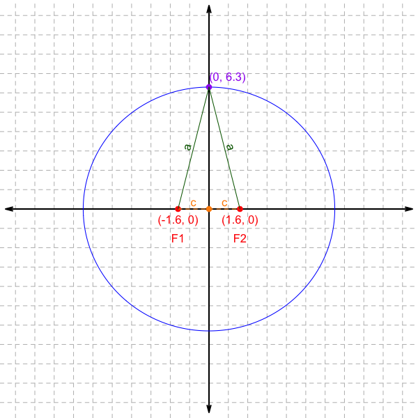

   Evaluate $2a$ and $2c$.
   - $a=$
   - $2a=$
   - $c=$
   - $2c=$

   Now, let’s pick another point on the ellipse, with (approximate) coordinates (3.67, 5.2):

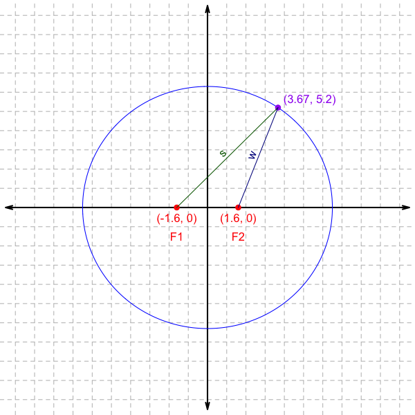

   The distance $s$ is from $F_1$ to the point on the edge. The distance $w$ is from $F_2$ to the point on the edge. Evaluate $s$, $w$, and the total distance ($s+w$).
   - $s=$
   - $w=$
   - $s+w=$

   Remember, the total distance when connecting
   1. The first focus $F_1$
   2. Any point on the edge
   3. The second focus $F_2$

   equals $2a$. Based on this information, find the location of the right vertex at ($x$, 0) in the diagram below.

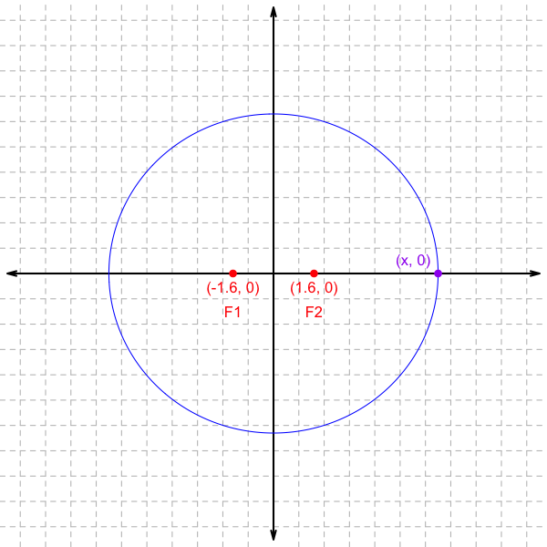

   - $x=$

#### Solution

#### Question

3. An [ellipse](https://en.wikipedia.org/wiki/Ellipse) is a set of points such that the total distance from (1) one focus to (2) the edge to (3) the other focus is constant for any point on the edge. The two foci ($F_1$ and $F_2$) are a distance $2c$ apart, and the total distance from $F_1$ to the edge to $F_2$ is a distance $2a$.

   Let’s consider the example below with foci at $(-5.6,0)$ and $(5.6,0)$ and a covertex at $(0, 3.3)$:

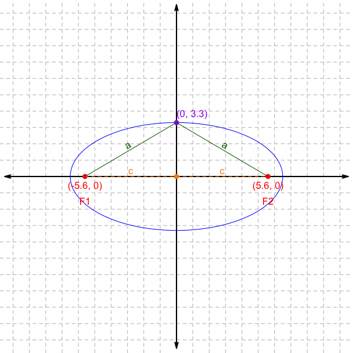

   Evaluate $2a$ and $2c$.
   - $a=$
   - $2a=$
   - $c=$
   - $2c=$

   Now, let’s pick another point on the ellipse, with (approximate) coordinates (5.57, 1.7):

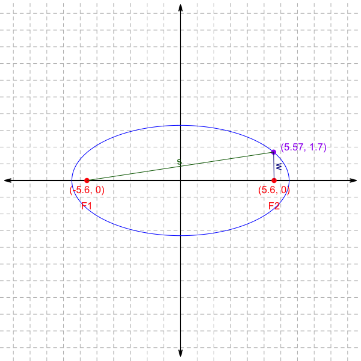

   The distance $s$ is from $F_1$ to the point on the edge. The distance $w$ is from $F_2$ to the point on the edge. Evaluate $s$, $w$, and the total distance ($s+w$).
   - $s=$
   - $w=$
   - $s+w=$

   Remember, the total distance when connecting
   1. The first focus $F_1$
   2. Any point on the edge
   3. The second focus $F_2$

   equals $2a$. Based on this information, find the location of the right vertex at ($x$, 0) in the diagram below.

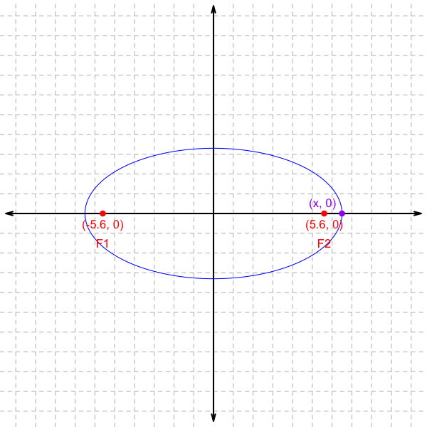

   - $x=$

#### Solution

#### Question

4. An [ellipse](https://en.wikipedia.org/wiki/Ellipse) is a set of points such that the total distance from (1) one focus to (2) the edge to (3) the other focus is constant for any point on the edge. The two foci ($F_1$ and $F_2$) are a distance $2c$ apart, and the total distance from $F_1$ to the edge to $F_2$ is a distance $2a$.

   Let’s consider the example below with foci at $(-4.5,0)$ and $(4.5,0)$ and a covertex at $(0, 2.8)$:

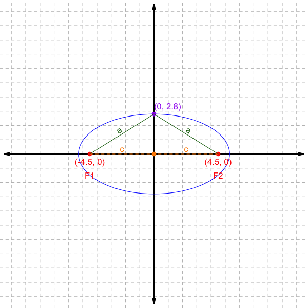

   Evaluate $2a$ and $2c$.
   - $a=$
   - $2a=$
   - $c=$
   - $2c=$

   Now, let’s pick another point on the ellipse, with (approximate) coordinates (2.59, 2.44):

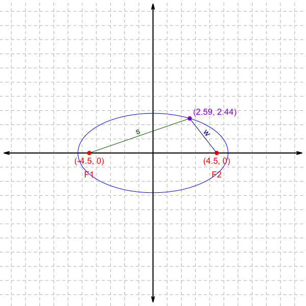

   The distance $s$ is from $F_1$ to the point on the edge. The distance $w$ is from $F_2$ to the point on the edge. Evaluate $s$, $w$, and the total distance ($s+w$).
   - $s=$
   - $w=$
   - $s+w=$

   Remember, the total distance when connecting
   1. The first focus $F_1$
   2. Any point on the edge
   3. The second focus $F_2$

   equals $2a$. Based on this information, find the location of the right vertex at ($x$, 0) in the diagram below.

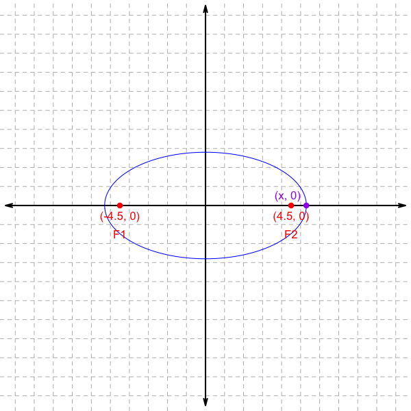

   - $x=$

#### Solution

#### Question

5. An [ellipse](https://en.wikipedia.org/wiki/Ellipse) is a set of points such that the total distance from (1) one focus to (2) the edge to (3) the other focus is constant for any point on the edge. The two foci ($F_1$ and $F_2$) are a distance $2c$ apart, and the total distance from $F_1$ to the edge to $F_2$ is a distance $2a$.

   Let’s consider the example below with foci at $(-1.1,0)$ and $(1.1,0)$ and a covertex at $(0, 6)$:

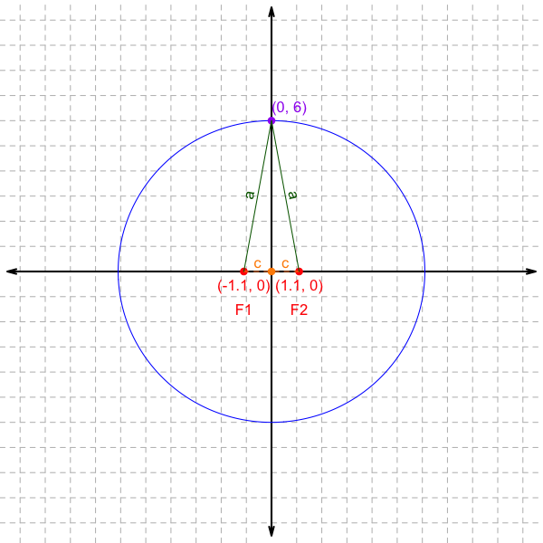

   Evaluate $2a$ and $2c$.
   - $a=$
   - $2a=$
   - $c=$
   - $2c=$

   Now, let’s pick another point on the ellipse, with (approximate) coordinates (5.53, 2.53):

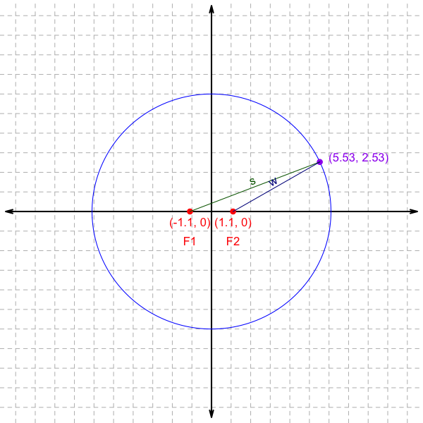

   The distance $s$ is from $F_1$ to the point on the edge. The distance $w$ is from $F_2$ to the point on the edge. Evaluate $s$, $w$, and the total distance ($s+w$).
   - $s=$
   - $w=$
   - $s+w=$

   Remember, the total distance when connecting
   1. The first focus $F_1$
   2. Any point on the edge
   3. The second focus $F_2$

   equals $2a$. Based on this information, find the location of the right vertex at ($x$, 0) in the diagram below.

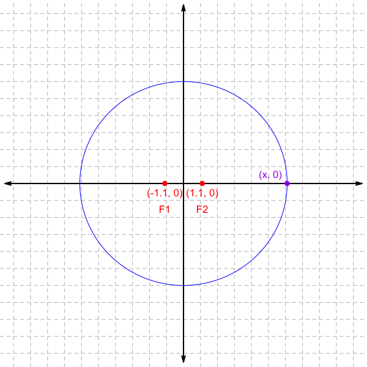

   - $x=$

#### Solution

#### Question

6. An [ellipse](https://en.wikipedia.org/wiki/Ellipse) is a set of points such that the total distance from (1) one focus to (2) the edge to (3) the other focus is constant for any point on the edge. The two foci ($F_1$ and $F_2$) are a distance $2c$ apart, and the total distance from $F_1$ to the edge to $F_2$ is a distance $2a$.

   Let’s consider the example below with foci at $(-3.6,0)$ and $(3.6,0)$ and a covertex at $(0, 7.7)$:

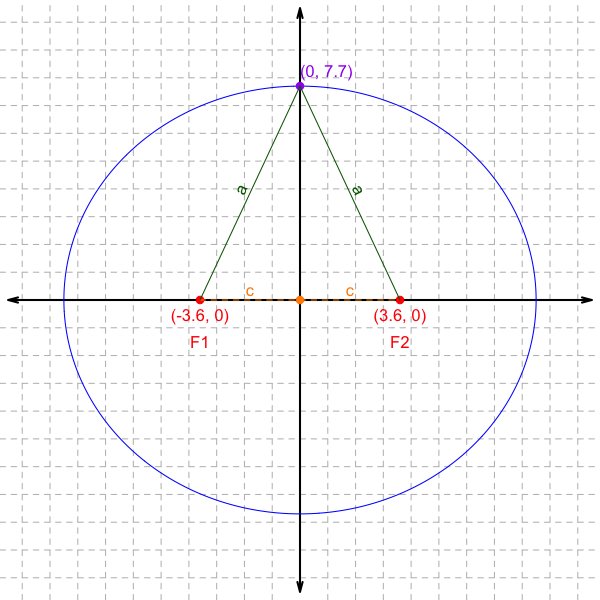

   Evaluate $2a$ and $2c$.
   - $a=$
   - $2a=$
   - $c=$
   - $2c=$

   Now, let’s pick another point on the ellipse, with (approximate) coordinates (4.49, 6.54):

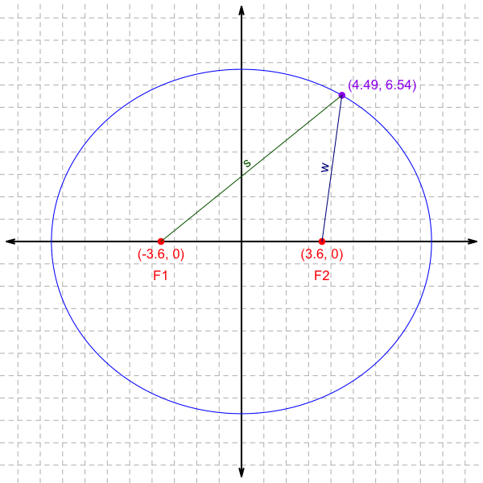

   The distance $s$ is from $F_1$ to the point on the edge. The distance $w$ is from $F_2$ to the point on the edge. Evaluate $s$, $w$, and the total distance ($s+w$).
   - $s=$
   - $w=$
   - $s+w=$

   Remember, the total distance when connecting
   1. The first focus $F_1$
   2. Any point on the edge
   3. The second focus $F_2$

   equals $2a$. Based on this information, find the location of the right vertex at ($x$, 0) in the diagram below.

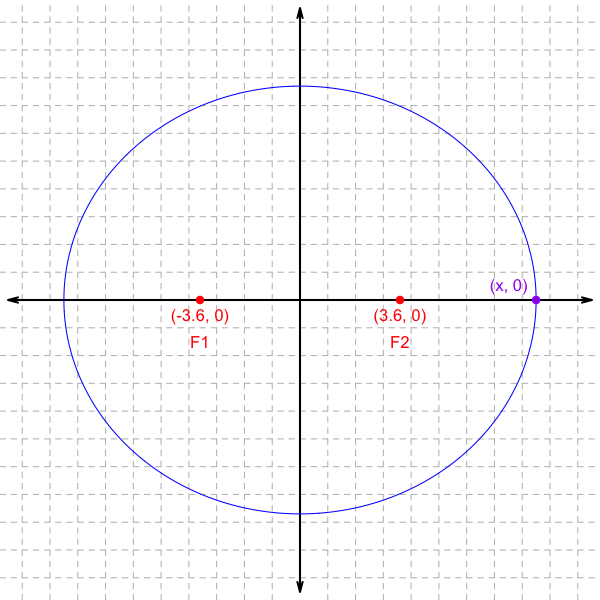

   - $x=$

#### Solution

#### Question

7. An [ellipse](https://en.wikipedia.org/wiki/Ellipse) is a set of points such that the total distance from (1) one focus to (2) the edge to (3) the other focus is constant for any point on the edge. The two foci ($F_1$ and $F_2$) are a distance $2c$ apart, and the total distance from $F_1$ to the edge to $F_2$ is a distance $2a$.

   Let’s consider the example below with foci at $(-8,0)$ and $(8,0)$ and a covertex at $(0, 3.9)$:

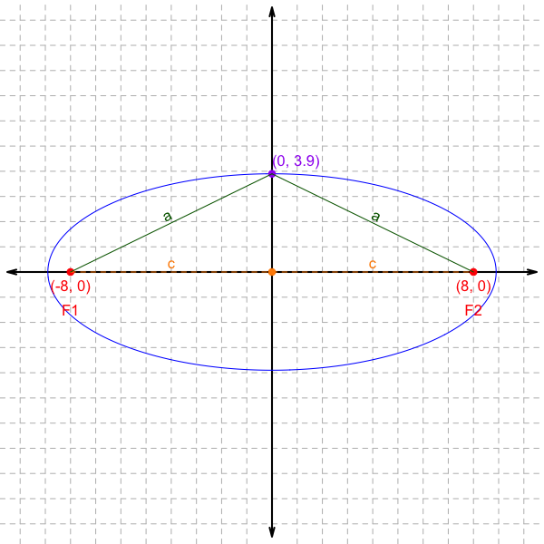

   Evaluate $2a$ and $2c$.
   - $a=$
   - $2a=$
   - $c=$
   - $2c=$

   Now, let’s pick another point on the ellipse, with (approximate) coordinates (7.9, 1.8):

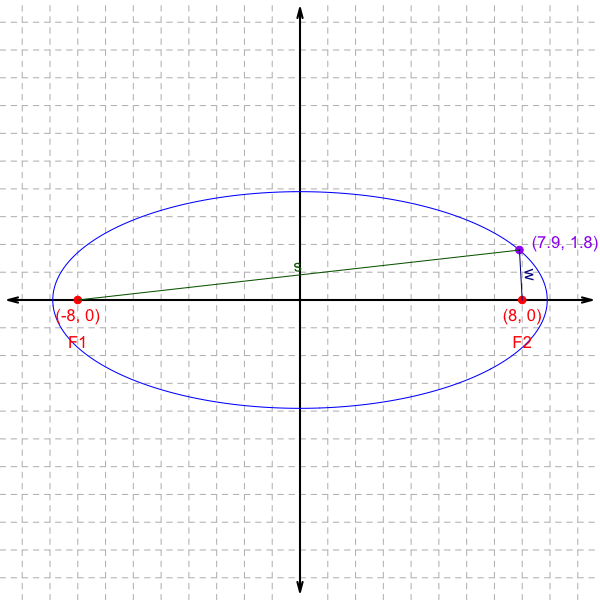

   The distance $s$ is from $F_1$ to the point on the edge. The distance $w$ is from $F_2$ to the point on the edge. Evaluate $s$, $w$, and the total distance ($s+w$).
   - $s=$
   - $w=$
   - $s+w=$

   Remember, the total distance when connecting
   1. The first focus $F_1$
   2. Any point on the edge
   3. The second focus $F_2$

   equals $2a$. Based on this information, find the location of the right vertex at ($x$, 0) in the diagram below.

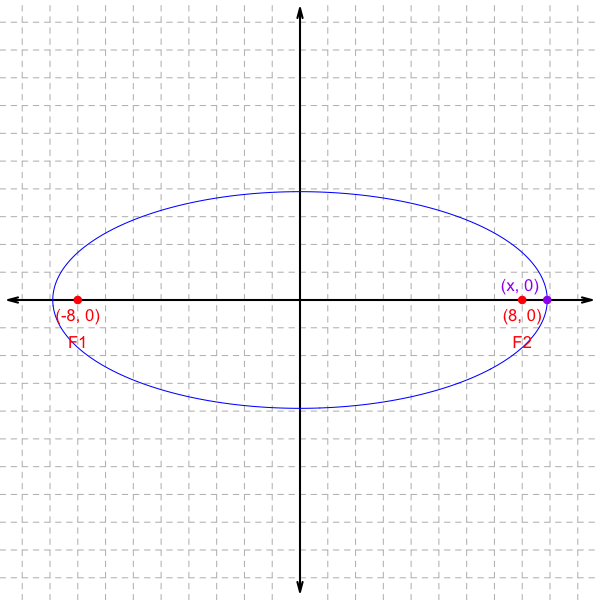

   - $x=$

#### Solution

#### Question

8. An [ellipse](https://en.wikipedia.org/wiki/Ellipse) is a set of points such that the total distance from (1) one focus to (2) the edge to (3) the other focus is constant for any point on the edge. The two foci ($F_1$ and $F_2$) are a distance $2c$ apart, and the total distance from $F_1$ to the edge to $F_2$ is a distance $2a$.

   Let’s consider the example below with foci at $(-2.4,0)$ and $(2.4,0)$ and a covertex at $(0, 4.5)$:

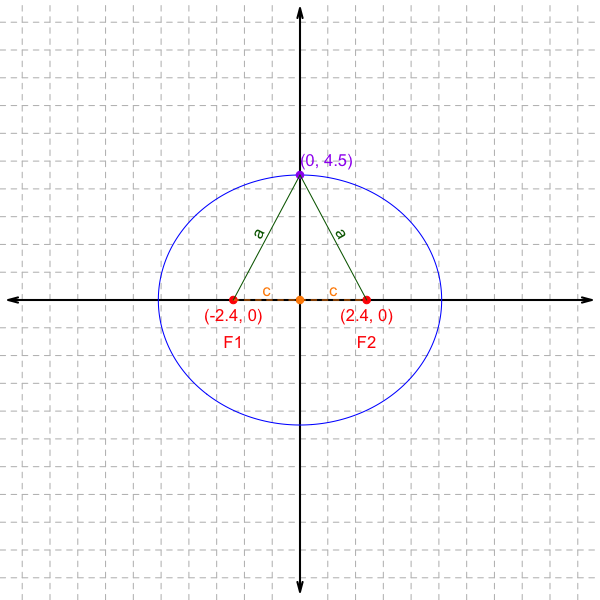

   Evaluate $2a$ and $2c$.
   - $a=$
   - $2a=$
   - $c=$
   - $2c=$

   Now, let’s pick another point on the ellipse, with (approximate) coordinates (3.61, 3.18):

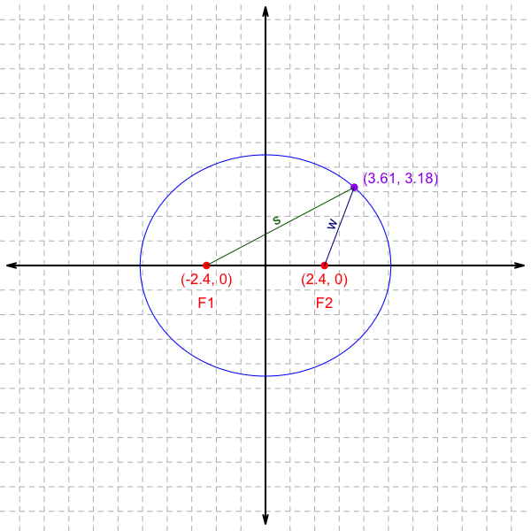

   The distance $s$ is from $F_1$ to the point on the edge. The distance $w$ is from $F_2$ to the point on the edge. Evaluate $s$, $w$, and the total distance ($s+w$).
   - $s=$
   - $w=$
   - $s+w=$

   Remember, the total distance when connecting
   1. The first focus $F_1$
   2. Any point on the edge
   3. The second focus $F_2$

   equals $2a$. Based on this information, find the location of the right vertex at ($x$, 0) in the diagram below.

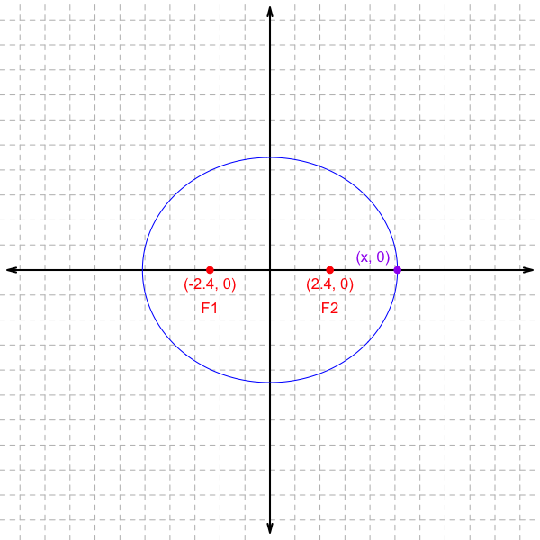

   - $x=$

#### Solution